# Assignment 3: ECDF and Bootstrap Sampling and Applications

Matthew Gray

Due: Tuesday 2/17/2026

## **Assignment Objectives**

- Understand the theoretical basis of Bootstrap sampling methods for approximating sampling distributions.
- Assess the performance of Bootstrap sampling distributions against exact and asymptotic sampling distributions.
- Implement Bootstrap sampling algorithm and construct sampling distributions using R.

**Use of AI Tools**

**Policy on AI Tool Use**: Students must adhere to the AI tool policy specified in the course syllabus. The direct copying of AI-generated content is strictly prohibited. All submitted work must reflect your own understanding; where external tools are consulted, content must be thoroughly rephrased and synthesized in your own words.

**Code Inclusion Requirement**: Any code included in your essay must be properly commented to explain the purpose and/or expected output of key code lines. Submitting AI-generated code without meaningful, student-added comments will not be accepted.

**Asymptotic Distribution of Sample Variance**

Assume that $\{ x_1, x_2, \cdots, x_n \} \to F(x)$ with $\mu = E[X]$ and $\sigma^2 = \text{var}(X)$. Denote

$$s^2 = \frac{1}{n-1}\sum_{i=1}^n (x_i - \mu)^2$$

If $n$ is large,

$$s^2 \to N\left(\sigma^2, \frac{\mu_4-\sigma^4}{n} \right)$$

where $\mu_4 = E[(X_i - \mu)^4]$ is tje 4th central moment which can be estimated by

$$\hat{\mu}_4 = \frac{1}{n}\sum_{i=1}^n(x_i-\bar{x})^4.$$

**Note**: This describes the asymptotic convergence of the sample variance, following from the central limit theorem (CLT). The sample size required for this approximation to hold is situation-dependent.

## **Question 1: Asymptotic vs Bootstrap Sampling Distributions**

Write an essay summarizing the concepts of Asymptotic and Bootstrap Sampling Distributions, along with their key applications. Your discussion should be grounded in your personal understanding of the material. Any external sources including AI tools consulted must be clearly cited.

**Essay Prompt**: Discuss the concepts of the bootstrap sampling plan, the bootstrap sampling distribution, and the asymptotic sampling distribution in the context of statistics (e.g., sample mean and variance) computed from an independent and identically distributed (i.i.d.) sample. Your discussion should:

- Clearly outline the key assumptions required for each method.
- Explain the practical application of each distribution.
- Provide guidance on when and why one should be preferred over the other in statistical inference.

**Essay Response**:

Last week we saw that many sampling distributions are known in closed form: under i.i.d. sampling from a Normal population, several statistics have exact sampling distributions, and when Normality is relaxed but the population has finite mean and variance, many statistics still have well-defined asymptotic distributions as the sample size approaches infinity. These theoretical results give us powerful tools for inference, but they rely on assumptions that may not always hold and can be difficult to put into practice. For example, what if we cannot assume the underlying population is Normal and what if you cannot collect very large samples or do not know how large a sample should be before we invoke the Central Limit Theorem? What is to be done then? We build simulations.

A Monte Carlo simulation generates large numbers of i.i.d. samples from a population, computes a statistic for each sample, and uses the resulting collection of statistics to form an empirical sampling distribution. With Monte Carlo, you can simulate how fast sampling distributions converge to their asymptotes as n increases. Monte Carlo therefore acts as a bridge between theory and practice, allowing us to compare these theoretical asymptotic results with the behavior we observe through repeated sampling. There is no need to collect samples that are infinitely large. There is no need to toil with math predicting what the exact and asymptotic distribution of your statistic may be. So long as you can assume access to the true population, you can simulate the distribution of your statistic.

But again, assuming that we have access to the true population tends to pose a significant barrier to application in the real world. Enter the Bootstrap Resampling Method. Here, we only assume we have access to a single representative random sample from the true population. We then sample with replacement from the original random sample to create large numbers of i.i.d. bootstrap samples (each simulated bootstrap sample must be the same size as the original random sample). Like Monte Carlo, we then compute a statistic for each bootstrap sample and use the resulting collection of statistics to form an empirical bootstrap sampling distribution.

So if you have a distribution free population, when can you get away with using Asymptotic approximations of sampling distributions and when should you turn to simulations? I think this is the question that is at the heart of this assignment and it is difficult to answer without lots of hands-on experience. The problem with asymptotes is that they are only valid so long as we are computing our statistic from a sample that is “large enough” such that we can invoke the Central Limit Theorem. We know that sampling statistics converge to a distribution as sample size grows large, but we do not know how fast this happens. In class we discussed how the the general rule of thumb from undergraduate statistics - that a sample size of 30 is “large enough” - is arbitrary. I think it is wise to pair Asymptotic approximations with a quick simulation whenever you are working with unfamiliar statistics and small to moderate sample sizes until you get a better understanding of the age-old question: how large is large enough?

## **Question 2: Daily Coffee Sales (in mL) at Two Different Cafe Locations**

```
2850, 3200, 2900, 3100, 2950, 7800, 8100, 7900, 3300, 3050, 4000, 4200, 3150, 3400, 7700, 8200,
3250, 4400, 3100, 4200, 4500, 4800, 4300, 8500, 8200, 8900, 8700, 3250, 3000, 4600, 4100, 8400,
8800, 3350, 4700, 3100, 8100, 3050, 8300, 4100, 3100, 8300, 8900, 8200, 4400, 4500, 3250, 4600,
8400, 3300, 4200, 4500, 4800, 4300, 8500
```

We are interested in finding the sampling distribution of sample means that will be used for various inferences about the underlying population mean.

1. Based on the given data, can the Central Limit Theorem be used to derive the asymptotic sampling distribution of the sample mean? Justify your answer.

**Answer**:

Yes. I have worked with the sample mean before. Sample size 𝑛 ≈ 50 is typically large enough to invoke the Central Limit Theorem for this statistic. As long as we are willing to treat the daily volumes as independent observations from a single population with finite variance, the Central Limit Theorem implies that the sampling distribution of the sample mean is approximately normal for this sample size. We can run a quick simulation and confirm this is valid.

2. Apply the bootstrap method to estimate the sampling distribution (often called the bootstrap sampling distribution) of the sample mean. Generate a kernel density estimate from the bootstrap sample means and plot it. Then, use this bootstrap distribution to validate your conclusion from part (a). Make sure your visuals are effective in enhancing the presentation of these results.

```r
# -----------------DEFINING THE BOOTSTRAP FUNCTION -----------------------------------------------------------------------
bootstrap <- function(data, statistic, B)
# bootstrap: function with three arguments
# data: the random sample from the population with which you will make bootstrap samples
# statistic: the statistical procedure you will apply to the bootstrap samples
# B: the number of bootstrap samples you plan to create
{
# this bracket begins the definition of the function
n <- length(data)
# n: the number of observations in your random sample
t_obs <- statistic(data)
# t_obs: the computed statistic for your original random sample. This only needs to be computed once.
# this will not become part of your bootstrap distribution. This is your actual estimate from the real world.
bootstrap_dist <- numeric(B)
# bootstrap_dist: empty vector of length B that will eventually store all the bootstrap statistics you will compute

for (b in 1:B)
{
# everything inside of this bracket will loop B times, filling the vector bootstrap_dist
indices <- sample(1:n, n, replace = TRUE)
# the sample function samples with replacement from the vector 1:n (the integers 1,2,3, ... n) until sample size is n
# the result is a vector called indices which stores the position of data values we'd like in our bootstrap sample
bootstrap_sample <- data[indices]
# we index our data with the indices vector to create our bootstrap sample
bootstrap_dist[b] <- statistic(bootstrap_sample)
# we compute the statistic of our bootstrap sample
# and then feed that value into our bootstrap distribution vector, filling in position b
}
# everything after this bracket is outside the loop

return(list(observed = t_obs, distribution = bootstrap_dist))
# This line returns a list with two named components so the bootstrap function can give back both the
# observed statistic and the entire sampling distribution. You need a list because you want to return a single number
# (t_obs) as well as a long numeric vector (bootstrap_dist). A vector can't hold both of those but a list can.
# observed = t_obs creates an element in the list named "observed". So after running the function, you can access
# it with result$observed. distribution = bootstrap_dist creates an element in the list named "distribution". After
# running the function, you can access this with result$distribution.
# Later, I will run the code boot_mean <- bootstrap(coffee_sales,mean,5000). boot_mean$distribution will give us the
# resulting distribution of running that function. boot_mean$observed will give us t_obs, the computed statistic for
# your original random sample. We will use these later when we are graphing.

}
# this bracket ends the definition of the function

# ----------- STORING THE RANDOM SAMPLE -----------------------------------------------------------------------------
coffee_sales <- c(2850, 3200, 2900, 3100, 2950, 7800, 8100, 7900, 3300, 3050, 4000, 4200, 3150, 3400, 7700, 8200,
3250, 4400, 3100, 4200, 4500, 4800, 4300, 8500, 8200, 8900, 8700, 3250, 3000, 4600, 4100, 8400,
8800, 3350, 4700, 3100, 8100, 3050, 8300, 4100, 3100, 8300, 8900, 8200, 4400, 4500, 3250, 4600,
8400, 3300, 4200, 4500, 4800, 4300, 8500)
# coffee_sales: stores all of the coffee sales as a vector
```

```r
# ------------- RUNNING THE FUNCTION ---------------------------------------------------------------------------------
boot_mean <- bootstrap(coffee_sales,mean,5000)
# boot_mean: stores the result of running my bootstrap function on the coffee_sales data set.
# 5000 bootstrap sample means were computed and stored in a list under the name distribution.
# 1 sample mean from the original random was computed and stored in a list under the name observed.

# ------------- STORING THE RESULTS ----------------------------------------------------------------------------------
boot_df_mean <- tibble(stat_mean = boot_mean$distribution)
# ggplot cannot take a raw numeric vector as input. It needs a data frame with named columns.
# boot_df_mean: stores our vector output as tibble (essentially a modern data frame) with column name stat

t_obs_mean <- boot_mean$observed
# t_obs_mean: stores our output observed statistic
```

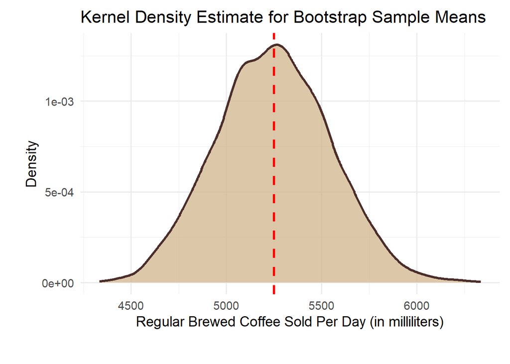

```r
# --------------- GRAPHING THE RESULTS --------------------------------------------------------------------------------
ggplot(boot_df_mean, aes(x = stat_mean)) +
# call the ggplot function. use boot_df_mean as your data. map the variable stat_mean to the x axis
geom_density(fill = "#D2B48C", alpha = 0.75, color = "#4B2E2B", linewidth = 1.2) +
# geom_density tells ggplot to fit a smooth kernel density estimate to the bootstrap values and draw it
# fill = "skyblue" fills the area under the density curve with a sky-blue color
# alpha = 0.75 controls transparency. I chose semi-transparent. 1 is fully opaque. 0 is completely transparent.
# color = "blue" sets the outline color of the density curve and linewidth = 1.2 controls the thickness of the outline
geom_vline(xintercept = t_obs_mean, color = "red", linetype = "dashed", linewidth = 1.2) +
# this line adds a vertical reference line to the bootstrap plot at the value of the observed statistic t_obs_mean
labs(
title = "Kernel Density Estimate for Bootstrap Sample Means",
x = "Regular Brewed Coffee Sold Per Day (in milliliters)",
y = "Density") +
# creates a title and labels for the x and y axes
theme_minimal(base_size = 14) +
# makes the plot clean, minimal, and easy to read, with slightly larger text
theme( plot.margin = margin(t = 10, r = 10, b = 35, l = 25) ) # this adds space outside the plot area to make axis titles less cramped
```

**Answer**:

The bootstrap sampling distribution of the sample mean appears approximately symmetric and bell-shaped, centered at the observed sample mean. This empirical distribution closely resembles a normal distribution. This supports the use of the Central Limit Theorem in part (a): for this sample size, the normal approximation for the sampling distribution of the mean is reasonable.

3. Repeat the analysis in parts (a) and (b) for the sample variance.

**Answer**:

Sample statistics converge to their asymptotic distributions at different rates. I have not worked a lot with variance, but I know it tends to converge more slowly than sample means. Rather than invoke the Central Limit Theorem with sample size 𝑛 ≈ 50 I think we should be a little more cautious and run a quick simulation to get a better idea of the sampling distribution.

```r
# ------------- RUNNING THE FUNCTION ---------------------------------------------------------------------------------
boot_var <- bootstrap(coffee_sales,var,5000)
# boot_mean: stores the result of running my bootstrap function on the coffee_sales data set.
# 5000 bootstrap sample means were computed and stored in a list under the name distribution.
# 1 sample mean from the original random was computed and stored in a list under the name observed.

# ------------- STORING THE RESULTS ----------------------------------------------------------------------------------
boot_df_var <- tibble(stat_var = boot_var$distribution)
# ggplot cannot take a raw numeric vector as input. It needs a data frame with named columns.
# boot_df_var: stores our vector output as tibble (essentially a modern data frame) with column name stat

t_obs_var <- boot_var$observed
# t_obs_var: stores our output observed statistic
```

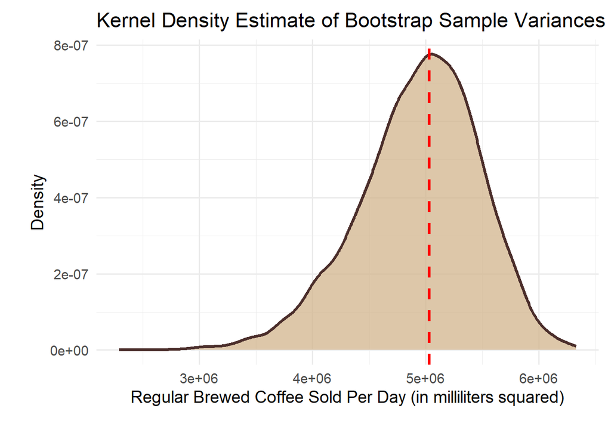

```r
# --------------- GRAPHING THE RESULTS --------------------------------------------------------------------------------
ggplot(boot_df_var, aes(x = stat_var)) +
# call the ggplot function. use boot_df_var as your data. map the variable stat_var to the x axis
geom_density(fill = "#D2B48C", alpha = 0.75, color = "#4B2E2B", linewidth = 1.2) +
# geom_density tells ggplot to fit a smooth kernel density estimate to the bootstrap values and draw it
# fill = "skyblue" fills the area under the density curve with a sky-blue color
# alpha = 0.75 controls transparency. I chose semi-transparent. 1 is fully opaque. 0 is completely transparent.
# color = "blue" sets the outline color of the density curve and linewidth = 1.2 controls the thickness of the outline
geom_vline(xintercept = t_obs_var, color = "red", linetype = "dashed", linewidth = 1.2) +
# this line adds a vertical reference line to the bootstrap plot at the value of the observed statistic t_obs_var
labs(
title = "Kernel Density Estimate of Bootstrap Sample Variances",
x = "Regular Brewed Coffee Sold Per Day (in milliliters squared)",
y = "Density") +
# creates a title and labels for the x and y axes
theme_minimal(base_size = 14) +
# makes the plot clean, minimal, and easy to read, with slightly larger text
theme( plot.margin = margin(t = 10, r = 10, b = 25, l = 25) ) # this adds space outside the plot area to make axis titles less cramped
```

**Answer**:

This empirical distribution does not closely resemble a normal distribution - it is skewed left. Perhaps if we had less variability (one instead of two coffee shops), we may have been able to overcome the small-medium sample size and converge to the asymptotically Normal distribution we may expect, but that was not the case here. It was a good idea not to jump straight to invoking the Central Limit Theorem in part (a).